# Part 2 — Citation graph: structural descriptions

### Self-citation

A self-citation is a citation from a paper to a work that shares an author with it. Authors match on family name and first initial, the rule used for the shared authors above. The counts cover the citations from annotated papers, which the seed filter leaves unchanged. “Any shared author” counts a citation when any author of the citing paper also wrote the cited work. “First author” counts it when the citing paper’s first author wrote the cited work.

Of the 21,124 citations from annotated papers to works with a known author list, 1,531 (7.2%) go to a work that shares an author with the citing paper and 893 (4.2%) go to a work by the citing paper’s first author. 311 of the 369 annotated papers cite at least one work they share an author with, and 283 cite at least one work by their first author.

**By year**

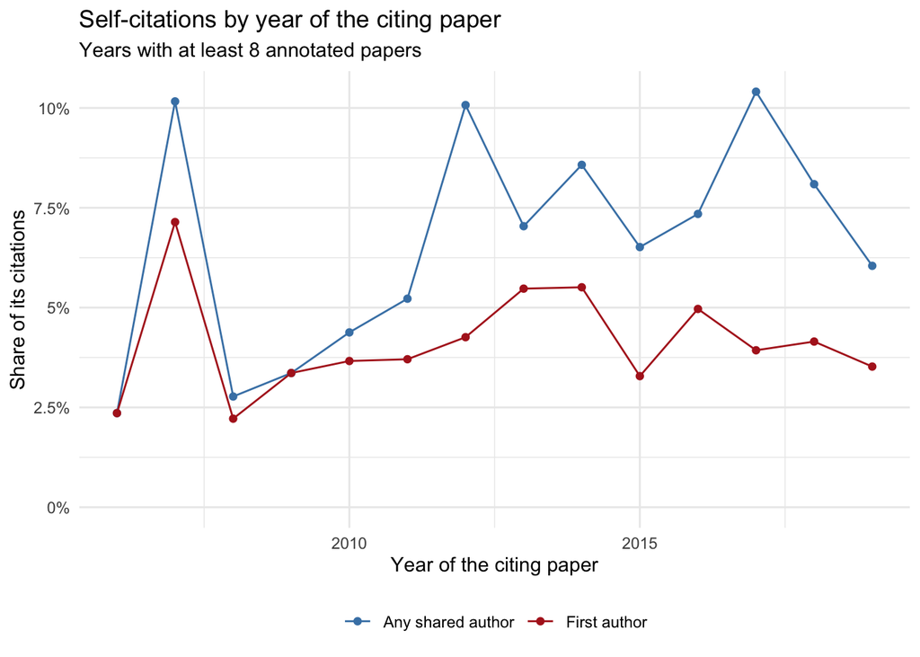

**Table, by year**

The plot’s numbers, with every year including the papers whose year is unknown. Papers is the number of annotated papers published that year, and Citations is the number of their citations to works with a known author list.

| Year of the citing paper | Papers | Citations | Any shared author | Any shared author (%) | First author | First author (%) |
| --- | --- | --- | --- | --- | --- | --- |
| 2000 | 1 | 125 | 2 | 1.6 | 2 | 1.6 |
| 2001 | 1 | 28 | 1 | 3.6 | 0 | 0.0 |
| 2002 | 1 | 47 | 0 | 0.0 | 0 | 0.0 |
| 2003 | 1 | 31 | 5 | 16.1 | 5 | 16.1 |
| 2004 | 7 | 228 | 8 | 3.5 | 8 | 3.5 |
| 2005 | 5 | 218 | 8 | 3.7 | 8 | 3.7 |
| 2006 | 8 | 297 | 7 | 2.4 | 7 | 2.4 |
| 2007 | 9 | 364 | 37 | 10.2 | 26 | 7.1 |
| 2008 | 9 | 541 | 15 | 2.8 | 12 | 2.2 |
| 2009 | 10 | 357 | 12 | 3.4 | 12 | 3.4 |
| 2010 | 18 | 1256 | 55 | 4.4 | 46 | 3.7 |
| 2011 | 22 | 1187 | 62 | 5.2 | 44 | 3.7 |
| 2012 | 24 | 1221 | 123 | 10.1 | 52 | 4.3 |
| 2013 | 35 | 1790 | 126 | 7.0 | 98 | 5.5 |
| 2014 | 37 | 1924 | 165 | 8.6 | 106 | 5.5 |
| 2015 | 35 | 1949 | 127 | 6.5 | 64 | 3.3 |
| 2016 | 32 | 1933 | 142 | 7.3 | 96 | 5.0 |
| 2017 | 37 | 2671 | 278 | 10.4 | 105 | 3.9 |
| 2018 | 43 | 2410 | 195 | 8.1 | 100 | 4.1 |
| 2019 | 24 | 1902 | 115 | 6.0 | 67 | 3.5 |
| 2020 | 7 | 449 | 38 | 8.5 | 25 | 5.6 |
| 2021 | 1 | 51 | 0 | 0.0 | 0 | 0.0 |
| Unknown | 2 | 145 | 10 | 6.9 | 10 | 6.9 |

**By number of authors**

The share by any shared author rises from 4% for single-author papers to 17.3% for papers with six or more authors, because each added author adds a chance of a match. The first-author share stays between 4% and 5.7%.

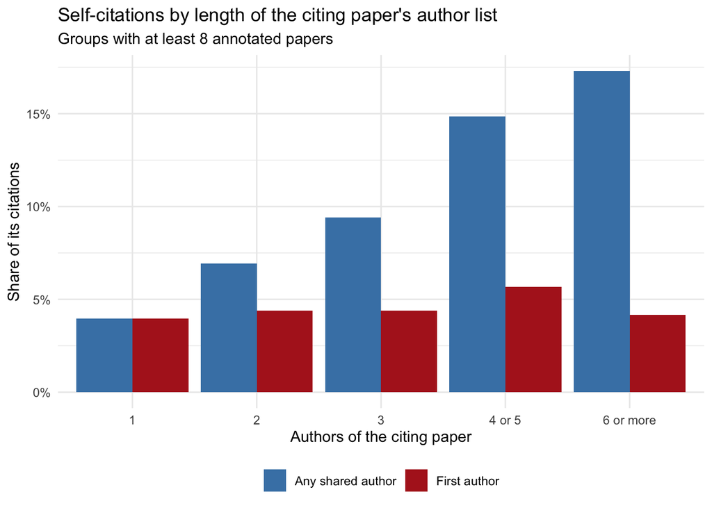

**Table, by number of authors**

The plot’s numbers.

| Authors of the citing paper | Papers | Citations | Any shared author | Any shared author (%) | First author | First author (%) |
| --- | --- | --- | --- | --- | --- | --- |
| 1 | 215 | 11929 | 473 | 4.0 | 473 | 4.0 |
| 2 | 66 | 3687 | 256 | 6.9 | 162 | 4.4 |
| 3 | 25 | 1392 | 131 | 9.4 | 61 | 4.4 |
| 4 or 5 | 31 | 1689 | 251 | 14.9 | 96 | 5.7 |
| 6 or more | 32 | 2427 | 420 | 17.3 | 101 | 4.2 |

**By cluster shape**

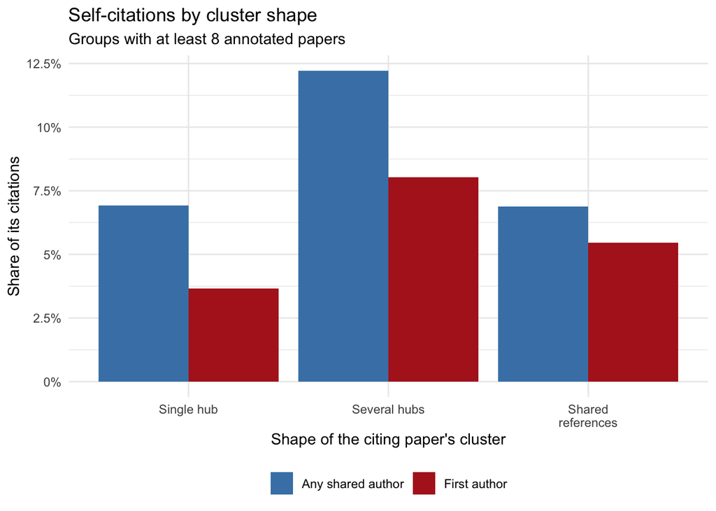

**Table, by cluster shape**

The plot’s numbers. The cluster of the citing paper decides the shape, and the table includes the groups the plot leaves out.

| Shape of the citing paper’s cluster | Papers | Citations | Any shared author | Any shared author (%) | First author | First author (%) |
| --- | --- | --- | --- | --- | --- | --- |
| Single hub | 274 | 16487 | 1140 | 6.9 | 605 | 3.7 |
| Several hubs | 42 | 1334 | 163 | 12.2 | 107 | 8.0 |
| Shared references | 52 | 3300 | 227 | 6.9 | 180 | 5.5 |
| Cluster of fewer than three papers | 1 | 3 | 1 | 33.3 | 1 | 33.3 |

**Most self-citing papers**

The fifteen annotated papers with the most citations to works that share an author with them.

| Paper | Authors | Citations | Any shared author | Any shared author (%) | First author |
| --- | --- | --- | --- | --- | --- |
| Last millennium Northern Hemisphere summer temperatures f… (2017) | 6 | 225 | 73 | 32.4 | 18 |
| Medieval Iceland, Greenland, and the New Human Condition:… (2017) | 6 | 149 | 49 | 32.9 | 2 |
| Disequilibrium, adaptation, and the Norse settlement of G… (2018) | 5 | 124 | 27 | 21.8 | 0 |
| Finding Vikings with Isotope Analysis: The View From Wet … (2014) | 6 | 95 | 26 | 27.4 | 17 |
| Single Context, Metacontext, and High Definition Archaeol… (2019) | 7 | 112 | 21 | 18.8 | 2 |
| Was It for Walrus? Viking Age Settlement and Medieval Wal… (2015) | 13 | 75 | 21 | 28.0 | 0 |
| Human Remains, Context, and Place of Origin for the Salme… (2020) | 5 | 60 | 18 | 30.0 | 11 |
| Urban Networks and Arctic Outlands: Craft Specialists and… (2015) | 3 | 119 | 18 | 15.1 | 8 |
| Cultural Adaptation, Compounding Vulnerabilities and Conj… (2012) | 6 | 48 | 18 | 37.5 | 2 |
| Integrated Microstratigraphic Investigations of Coastal A… (2013) | 5 | 50 | 17 | 34.0 | 11 |
| Norse Greenland Settlement: Reflections on Climate Change… (2007) | 3 | 70 | 17 | 24.3 | 8 |
| Migration and Viking Dublin: Paleomobility and paleodiet … (2012) | 5 | 152 | 17 | 11.2 | 1 |
| Expensive errors or rational choices: the pioneer fringe … (2014) | 5 | 49 | 16 | 32.7 | 13 |
| Isotopic Investigation of Human Provenience at the Eleven… (2012) | 8 | 60 | 16 | 26.7 | 7 |
| Finding Vikings in the Danelaw (2014) | 9 | 61 | 16 | 26.2 | 5 |

## What the seed filter changes

### What separates

Annotated has 1 weakly connected component(s) and Annotated, seed filtered has 3: a main body of 12,675 works and 2 smaller fragments of 12, 9 works. In Annotated those fragments join the main body only through the seed’s citations.

**NoteThe fragments**

| Fragment size | Year | Title |
| --- | --- | --- |
| 12 | 1953 | The Fragmentation of Coins in Early Medieval East Central Europeʼ |
| 12 | 1961 | ʻCoin Finds and the Problem of Money Hoarding in Early Medieval Polandʼ |
| 12 | 1987 | The Tenth Century Máramaros County (ʻHusztʼ) Dirham Hoard |
| 12 | 1994 | ʻWczesnośredniowieczny Skarb Srebrny Dzierznica II |
| 12 | 2006 | ʻSilver Handling Traditions During the Viking Age: Some Observations and Thoughts on the Phenomenon of Pecking and Bendingʼ |
| 12 | 2008 | ʻWeights and Measures in Islamʼ |
| 12 | 2009 | Najstarsze Państwo Piastów-Rezultat Przełomu czy Kontynuacji? |
| 12 | 2009 | ʻSpillings-the Largest Viking Age Silver Hoard in the Worldʼ |
| 12 | 2011 | Use of Money in the Slavic Lands from the Ninth to the Eleventh Century: the Archaeological/Numismatic Evidence |
| 12 | 2014 | Bezliudovskii Klad X v |
| 12 | 2015 | ʻWer Brachte im 10 |
| 12 | 2018 | Silver Fragmentation: Reinterpreting the Evidence of the Hoards |
| 9 | 1924 |  |
| 9 | 1930 | Article Title Not Explicitly Stated |
| 9 | 1994 |  |
| 9 | 1994 |  |
| 9 | 1996 | Традиция изгот |
| 9 | 1997 |  |
| 9 | 2012 |  |
| 9 | 2015 | Ладожские Бастионы и Горизонт В Земляного Городища (Проблема Хронологии) |
| 9 | 2018 | Stratigrafiya Zemlyanogo gorodishcha Staroy Ladogi: Itogi i perspektivy issledovaniy |

### Centrality

The comparison covers the works present in both graphs, with ghost entries excluded. A Spearman correlation near 1 and a large top-20 overlap mean the seed’s citations barely change a measure’s ranking. Betweenness is zero for most works. The seed filter takes nonzero betweenness away from 138 works that had it in Annotated and gives it to 0. The second table lists the ten works whose betweenness rank moves the most among the 231 that have nonzero betweenness in both graphs.

| Measure | Spearman correlation | Top 20 in both |
| --- | --- | --- |
| In-degree | 0.979 | 18 |
| Betweenness | 0.795 | 20 |
| PageRank | 1.000 | 20 |
| Coreness | 1.000 | 20 |

| Work | Year | Title | Rank, Annotated | Rank, seed filtered | Places gained |
| --- | --- | --- | --- | --- | --- |
| magi2011viking | 2011 | Viking Age and Early Medieval Eastern Baltic between the West and the East | 194 | 205 | -11 |
| svendsen2016how | 2016 | How did trade norms evolve in Scandinavia? Long-distance trade and social trust in the Viking Age | 197 | 207 | -10 |
| andersson2008hvorfor | 2008 | Hvorfor de første 200 årene? en introduksjon. de første 200 årene-nytt blikk på 27 skandinaviske middelalderbyer | 217 | 208 | 9 |
| wouters2016soil | 2016 | Soil Micromorphology in Urban Research: Early Medieval Antwerp (Belgium) and Viking Age Kaupang (Norway) | 214 | 222 | -8 |
| imer2014danish | 2014 | The Danish runestones: When and where? | 209 | 217 | -8 |
| lia2004vikingetidsgravenes | 2004 | Vikingetidsgravenes Rituelle Kompleksitet | 207 | 199 | 8 |
| hilberg2016hedeby | 2016 | Hedeby’s Demise in the Late Viking Age and the Shift to Schleswig | 179 | 186 | -7 |
| macphail2016microstratigraphy | 2016 | Microstratigraphy (Soil Micromorphology and Microchemistry, Soil Chemistry and Magnetic Susceptibility) | 201 | 194 | 7 |
| toplak2017deviant | 2017 | “Deviant Burials” Und Bestattungen in Bauchlage Als Teil Der Norm: Eine Fallstudie Am Beispiel Der Wikingerzeit Gotlands | 206 | 213 | -7 |
| skre2011inhabitantsactivities | 2011 | The Inhabitants: Activities | 195 | 188 | 7 |

### Communities

Partition agreement is measured on the nodes both graphs share. The adjusted Rand index and normalized mutual information both measure how much two partitions agree, from 0 for no more agreement than chance to 1 for identical groupings. Louvain and Leiden are rerun on each graph, and the Girvan-Newman partitions are the earliest fragmentation-onset cuts of the two runs. The last two rows rerun each algorithm on the Annotated graph with a different random seed. They show how much of the disagreement comes from the algorithm’s own randomness and not from the seed filter.

| Method | Adjusted Rand index | Normalized mutual information | Nodes compared |
| --- | --- | --- | --- |
| Girvan-Newman, earliest cut | 0.893 | 0.957 | 12,696 |
| Louvain | 0.636 | 0.821 | 12,696 |
| Leiden | 0.672 | 0.802 | 12,696 |
| Louvain, Annotated against its own rerun | 0.628 | 0.809 | 12,697 |
| Leiden, Annotated against its own rerun | 0.694 | 0.823 | 12,697 |

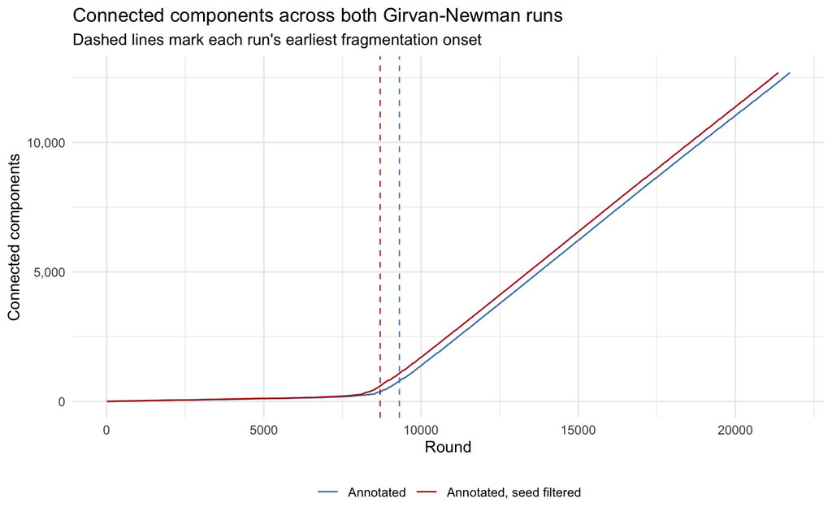

Each of the largest Annotated clusters, with the seed-filtered cluster that shares the most nodes with it. The share is the fraction of the Annotated cluster that lands in that match, and the Jaccard index is the overlap divided by the union of the two clusters.

| Cluster (Annotated) | Size | Best match (seed filtered) | Shared nodes | Share of cluster | Jaccard |
| --- | --- | --- | --- | --- | --- |
| Causal explanations for Viking expansion | 111 | Causation and environmental drivers of Viking expansion | 110 | 99% | 0.95 |
| Last millennium climate reconstruction methods | 81 | Methodologies for reconstructing past millennium climates | 81 | 100% | 0.83 |
| Archaeological Excavation Standards and Stratigraphy | 81 | Stratigraphic Excavation and Microstratigraphy Methods | 79 | 98% | 0.98 |
| North Atlantic Settlement, Economy, and Environment | 81 | North Atlantic Agricultural Landscapes and Collapse | 76 | 94% | 0.84 |
| Viking Age Farmsteads and Domestic Spaces | 81 | Viking-Age Domestic Architecture and Gendered Spaces | 80 | 99% | 0.88 |
| Urban Origins and Development in Southern Scandinavia | 81 | Archaeology of early urbanization in Southern Scandinavia | 81 | 100% | 0.83 |
| Paleodiet and Human Mobility via Isotope Analysis | 81 | Isotopic analysis for determining migration and diet in prehistory | 79 | 98% | 0.79 |
| Runic Inscriptions and Epigraphy | 81 | Interpretation and iconology of runic monuments | 80 | 99% | 0.81 |
| Theoretical and Critical Approaches to Archaeology | 81 | Archaeological theory and the Anthropocene perspective | 81 | 100% | 0.83 |
| Political power and ritual landscapes | 81 | Beowulf and Germanic Literary History | 78 | 96% | 0.85 |
| Methodological approaches to stone iconography | 81 | Iconography and interpretation of Gotlandic picture stones | 81 | 100% | 0.83 |
| Archaeology and anthropology of childhood | 81 | Construction of gender and masculinity in Viking Age Scandinavia | 81 | 100% | 0.83 |
| Archaeology of ship burials and dating | 81 | Archaeology and experimental reconstruction of Viking ships | 78 | 96% | 0.77 |
| Social-ecological systems in medieval North Atlantic | 81 | Environmental history and climate impacts in medieval Iceland and Greenland | 81 | 100% | 0.83 |
| Adaptive strategies in Norse Greenland colonization | 81 | Norse Settlement Ecology and Niche Construction in Greenland | 73 | 90% | 0.82 |
| Genomic analysis of Viking Age fisheries | 81 | Ancient DNA and Fish Subsistence in the North Atlantic | 81 | 100% | 0.99 |
| Ethnicity and inter-cultural contact in Sámi-Norse borderlands | 81 | Sámi-Norse Borderland Archaeology | 81 | 100% | 0.85 |
| Remote Sensing and Digital Landscape Analysis | 80 | Automated Detection of Viking Age Fortresses | 80 | 100% | 1.00 |
| Human Mobility and Migration Studies | 79 | Mobility and Settlement Patterns | 79 | 100% | 1.00 |
| Geophysical Prospection Methods and Applications | 78 | Geophysical Methods in Landscape Archaeology | 78 | 100% | 1.00 |

645 of the 12,696 nodes in both partitions (5.1%) sit outside the best-matching cluster of their Annotated cluster.

## Appendix: layout trials

The partition plots above use the Fruchterman-Reingold layout (`fr`, 500 iterations, with igraph’s grid speed-up). The layouts below were tried and are kept for reference with `eval: false`. Each calls the same plotting function as the main plots, so any of them can be switched on one at a time and run on either graph.

- `fr` spreads the papers that cite a hub around it, so each community reads as a region of the plot. It runs in seconds on either graph.
- `lgl` with `coolexp` lowered to 0.5, the layout used before, stretches the graph into one diagonal band and leaves the highlighted communities overlapping through its middle. It is also far slower than `fr` on the seed-filtered graph.
- `drl` stacks the papers that cite a hub on top of it, so every community collapses into a single dot and the plot shows nothing of its shape.
- `stress` (`graphlayouts::layout_with_stress()`) is faster than `drl` and built to preserve graph distance. It produced a concentric-ring pattern and was rejected.
- Untuned `lgl` places a handful of true outliers far from the rest. That is why the main plots crop the view to the 1st to 99th percentile.
- `lgl` with `repulserad` doubled spread the periphery out and left the inner core dense. `repulserad` sets the distance at which repulsion stops acting and does not change its strength, so it is the wrong lever for core density.

The Louvain, Leiden and K-means plots, also disabled. Each saves a PNG and a PDF next to this document.

## Node-table export

`analysis/bibvik_node_table.csv`, which `03_joined_descriptions.qmd` reads, holds the Annotated graph’s measures with one row per node, plus `community_gn` from the Annotated run’s earliest cut and `community_gn_seed_filtered` from the seed-filtered run. `group_gn` and `group_gn_seed_filtered` hold the consensus group of each paper’s cluster. `shape_gn` and `shape_gn_seed_filtered` hold the shape of each paper’s cluster, and `cluster_hub_gn` and `cluster_hub_gn_seed_filtered` mark the papers that cite other members of their cluster. `citations_known_authors`, `self_citations_any_author` and `self_citations_first_author` count each annotated paper’s citations to works with a known author list, and how many of those go to a work that shares an author with the paper or with its first author. The Girvan-Newman columns are left out when a run has not been installed.

## References

Alvarez-Hamelin, José Ignacio, Luca Dall’Asta, Alain Barrat, and Alessandro Vespignani. 2005. “Large Scale Networks Fingerprinting and Visualization Using the k-Core Decomposition.” *Advances in Neural Information Processing Systems* 18.

Blondel, Vincent D., Jean-Loup Guillaume, Renaud Lambiotte, and Etienne Lefebvre. 2008. “Fast Unfolding of Communities in Large Networks.” *Journal of Statistical Mechanics: Theory and Experiment* 2008 (10): P10008.

Fortunato, Santo. 2010. “Community Detection in Graphs.” *Physics Reports* 486 (3-5): 75–174.

Girvan, Michelle, and Mark E. J. Newman. 2002. “Community Structure in Social and Biological Networks.” *Proceedings of the National Academy of Sciences* 99 (12): 7821–26. https://doi.org/10.1073/pnas.122653799.

Good, Benjamin H., Yves-Alexandre de Montjoye, and Aaron Clauset. 2010. “The Performance of Modularity Maximization in Practical Contexts.” *Physical Review E* 81 (4): 046106.

Newman, Mark E. J. 2006. “Modularity and Community Structure in Networks.” *Proceedings of the National Academy of Sciences* 103 (23): 8577–82.

Newman, Mark EJ, and Michelle Girvan. 2004. “Finding and Evaluating Community Structure in Networks.” *Physical Review E* 69 (2): 026113. https://doi.org/10.1103/PhysRevE.69.026113.

Traag, V. A., L. Waltman, and N. J. van Eck. 2019. “From Louvain to Leiden: Guaranteeing Well-Connected Communities.” *Scientific Reports* 9:5233.

## Footnotes

[^1]: The proportion of possible edges that actually exist: edges present divided by every pair of nodes that *could* be connected. Low density is normal and expected for a citation network — most works don’t cite most other works.
[^2]: A weakly connected component treats every edge as undirected: two nodes are in the same component if a path connects them in either citation direction. This is the more forgiving of the two measures here.
[^3]: A strongly connected component requires an actual directed path in *both* directions between two nodes. Rare in citation networks, since citations are historically directed — a 2010 paper cannot cite a 2020 paper — so most strongly connected components are single isolated nodes.
[^4]: A LOESS fit, not a strict linear one, to allow for a non-constant relationship across the full year range rather than forcing a single slope.